# Pakiet ggplot2 - poziom zaawansowany

pogRomcy danych

sezon 3 / odcinek 3  
Naciśnij `A` by zamienić slajdy na ciągły tekst.  
Naciśnij `T` by wyświetlić spis treści.

# O czym jest ten odcinek

Funkcje z pakietu ggplot2 wyglądają dobrze przy domyślnych ustawieniach. Ale tworząc bardziej złożoną grafikę, często pojawia się potrzeba zmiany jakiegoś detalu.

W tym odcinku nauczymy się:

- Jak dodać adnotacje do wykresu?
- Jak zmieniać mapowania kształtu?
- Jak zmieniać mapowania kolorów?
- Jak modyfikować legendę?
- Jak zmieniać motywy graficzne wykresu?

# Adnotacje

Bardzo ważnym, a często niedocenianym elementem wykresu, są tytuły i opisy.

Dlaczego ważnym? Ponieważ bez tytułów i opisów czytelnik może nie mieć pojęcia co wykres przedstawia. Jeżeli czytelnik nie wie co wykres przedstawia to taki wykres jest bezużyteczny.

Dlaczego niedocenianym? Ponieważ twórca wykresu zazwyczaj wie co wykres przedstawia i niekoniecznie ma ochotę i czas by dbać o czytelnika.

Będziemy tworzyć bardzo dobre wykresy, ponieważ na naszych wykresach wszystko będzie jasne i opisane. Przyjrzyjmy się wykresowi z pierwszego odcinka i zastanówmy się które elementy warto dodatkowo opisać? Poświęć kilka minut by znaleźć przynajmniej pięć elementów, które warto lepiej opisać na tym wykresie.

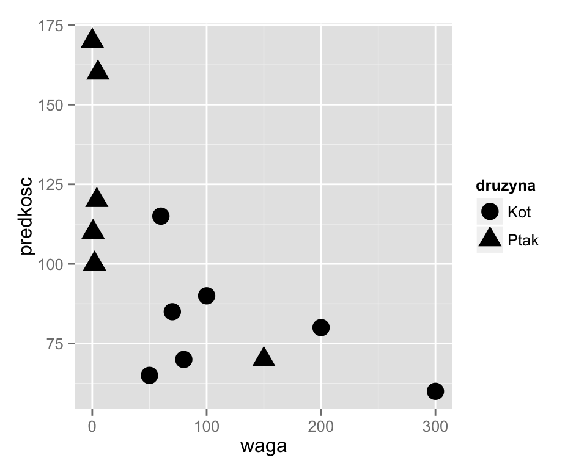

```r
library(PogromcyDanych)
ggplot(koty_ptaki, aes(x=waga, y=predkosc, shape=druzyna)) +
  geom_point(size=5)
```

# Adnotacje

Czy to było trudne zadanie?

Mogło tak być, ponieważ widzieliśmy ten wykres już wiele razy i wiemy co on przedstawia. Jeżeli jednak udało Ci się znaleźć elementy, warto dodatkowego opisu to świetnie, jesteś na dobrej ścieżce.

Oto co ja znalazłem

- W opisach osi brakuje jednostek. Jest informacja ‘waga’ ale w jakich to jednostkach? Kilogramach, funtach?
- Podobny problem dotyczy prędkości, czy to kilometry na godzinę czy mile?
- Opis legendy ‘druzyna’ może i jest zabawny ale niewiele mówi. Jaka drużyna? Dla kogoś, kto nie wie o wyścigach gatunków ten napis nic nie powie.
- Ale o co chodzi z tym wykresem? Gdzie jest tytuł? Co on w ogóle przedstawia?
- Jakie gatunki reprezentują najbardziej skrajne punkty? Który kot i który ptak jest najszybszy?

Zobaczmy jak przygotować wykres z odpowiednimi adnotacjami

# Adnotacje

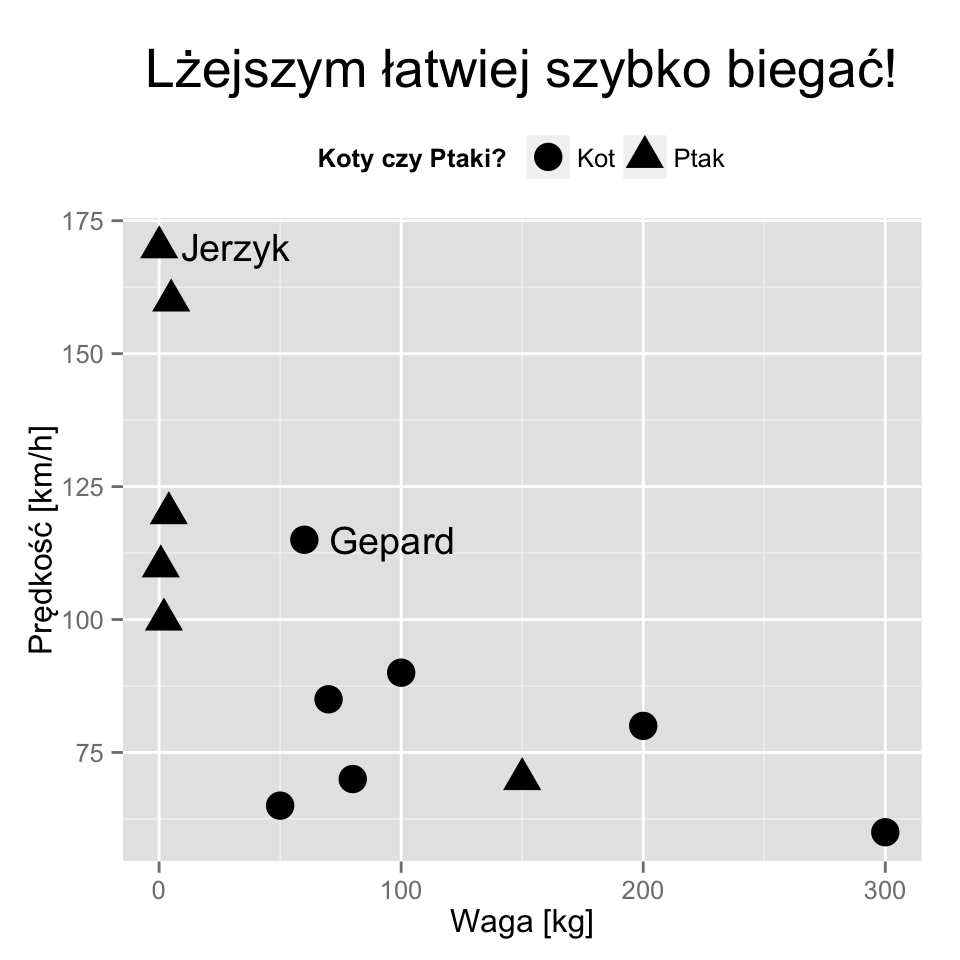

```r
ggplot(koty_ptaki, aes(x=waga, y=predkosc, shape=druzyna)) +
  geom_point(size=5) +
  ggtitle("Lżejszym łatwiej szybko biegać!") + theme(plot.title = element_text(size=20)) +
  xlab("Waga [kg]") + ylab("Prędkość [km/h]") +
  scale_shape_discrete(name="Koty czy Ptaki?") + theme(legend.position="top") +
  geom_text(data=koty_ptaki[c(6,8),], aes(label=gatunek), hjust=-0.2)
```

# Mapowania

Jedną z zalet pakietu `ggplot2` jest to, że wystarczy że wskażemy jakie zmienne mają być przedstawione na wykresie, oraz jakie cechy wykresu mają te zmienne opisać. R automatycznie dobiera sposób prezentacji uwzględniając typ zmiennej, czy przyjmuje ona kilka wartości czy wiele, czy jest zmienną ilościową czy jakościową itp.

Czasem jednak, chcielibyśmy zmienić sposób reprezentacji zmiennych. Możemy to zrobić korzystając z funkcji `scale_xxx_yyy()` gdzie `xxx` opisuje cechę na której mapujemy a `yyy` opisuje sposób reprezentacji. Przykładowo, funkcja `scale_shape_manual()` pozwala na zarządzanie mapowaniem zmiennej na kształty. Argument `values=` pozwala na wskazanie jakimi wartościami mają być przedstawione poszczególne grupy, argument `breaks=` pozwala wskazać kolejność poziomów w legendzie. W podobny sposób `scale_color_manual()` pozwala na podanie kolorów, jakie mają kodować zmienne. Dla mapowania na cechy `x` i `y` wykresy interesującym parametrem jest `expand=`, który pozwala na określenie jak duże mają być marginesy na osi.

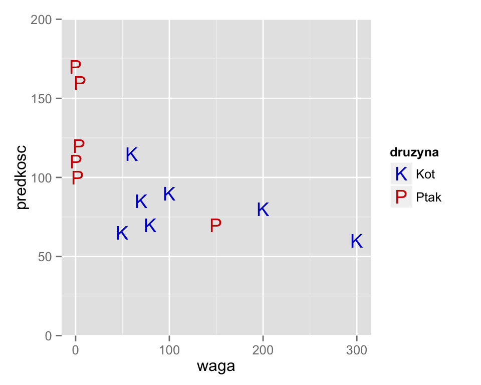

```r
ggplot(koty_ptaki, aes(x=waga, y=predkosc, shape=druzyna, color=druzyna)) +
  geom_point(size=5) +
  scale_shape_manual(values=c("K", "P"), breaks=c("Kot", "Ptak")) +
  scale_color_manual(values=c("blue3", "red3"), breaks=c("Kot", "Ptak")) +
  scale_y_continuous(limits=c(0,200), expand=c(0,0))
```

# Mapowania

Zobaczmy jak wygląda kontrolowanie mapowaniami zmiennych ciągłych. Tym razem na kolor i wielkość punktu zamapujemy ciągłą zmienną `zywotnosc`. Jeżeli nie podoba nam się domyślny dobór kolorów, to funkcją `scale_color_gradient()` możemy określić pomiędzy jakimi wartościami `low=` i `high=` ma rozpinać się skala kolorów. Dla wielkości punktu określamy jaki przedział żywotności ma być prezentowany `limits=` oraz na jakiej wielkości punkty ten przedział ma być przedstawiony `range=`.

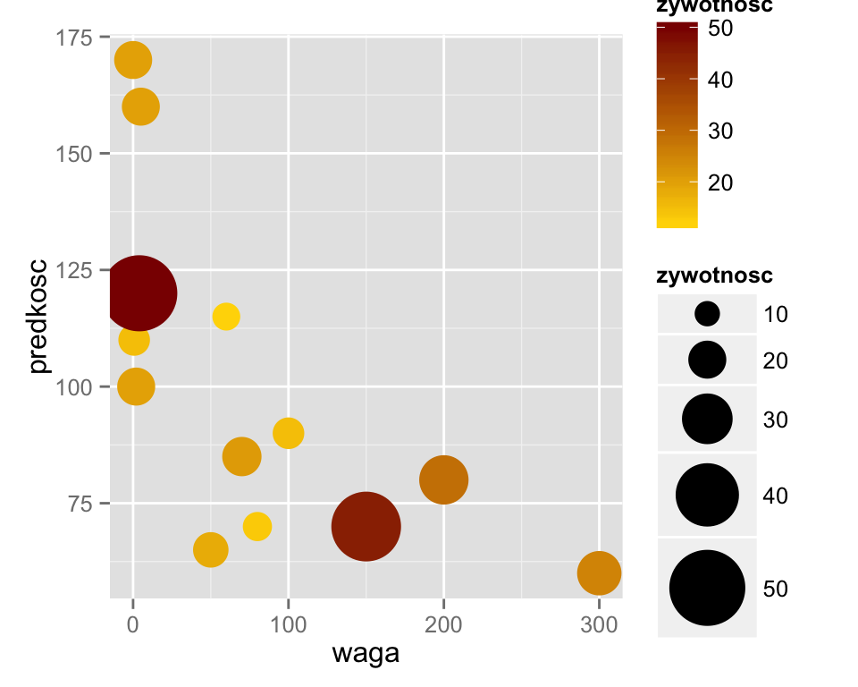

```r
ggplot(koty_ptaki, aes(x=waga, y=predkosc, size=zywotnosc, color=zywotnosc)) +
  geom_point() +
  scale_size_continuous(range=c(5,15), limits=c(10,50)) +
  scale_color_gradient(low="gold", high="red4")
```

# Legenda

Pakiet `ggplot2` automatycznie tworzy i rysuje legendę. W wielu przypadkach to domyślne zachowanie jest wystarczające, ale czasem chcemy umieścić tę legendę w innym miejscu, inaczej ją zatytułować czy pokolorować.

Oczywiście to wszystko możemy zrobić, ustawiając poszczególne argumenty motywu (funkcją `theme()`) lub funkcji mapujących.

W poniższym przykładzie funkcja `theme()` służy do określenia koloru tła i obramowania w legendzie, wielkość tytułu legendy oraz jej pozycję. Funkcja `scale_shape_manual()` określa elementy mapowania, tytuł legendy i nazwę kluczy na legendzie.

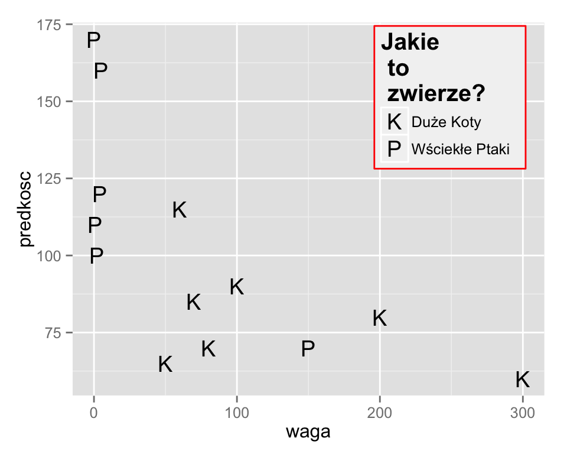

```r
ggplot(koty_ptaki, aes(x=waga, y=predkosc, shape=druzyna)) +
  geom_point(size=5) +
  scale_shape_manual(values=c("K", "P"), labels=c("Duże Koty", "Wściekłe Ptaki"), name="Jakie \n to \n zwierze?") +
  theme(legend.background = element_rect(color="red", fill="grey95"),
        legend.title = element_text(size=15),
        legend.position=c(0.8,0.8)) # 0.8, 0.8 to współrzędne gdzie ma pojawić się legenda
```

# Wiele wykresów w jednym oknie

W programie R wszystko jest obiektem. Oznacza to, że również wynik funkcji `ggplot()` jest obiektem, który można przypisać do zmiennej i później wielokrotnie wykorzystać. Zilustrujmy to przykładem. Poniższa instrukcja przypisze definicje wykresy do zmiennej `pl_waga`. Żaden wykres nie będzie narysowany chyba, że wyświetlimy zawartość zmiennej `pl_waga`.

```r
pl_waga <- ggplot(koty_ptaki, aes(x=waga, y=predkosc)) +
                geom_point(size=5)
```

Aby wyświetlić wykres `pl_waga` można wykorzystać funkcję `print()`. Jednym z argumentów tej funkcji jest `vp=` pozwalający określić w którym miejscu wykres ma być rysowany. Domyślnie zarysowany jest cały obszar o współrzędnych [0-1], ale możemy zażyczyć sobie by wykres rysowany był w mniejszym obszarze. Jest to bardzo wygodne, jeżeli chcemy zmieścić kilka wykresów obok siebie. Poniższy przykład rysuje ten sam wykres trzykrotnie, za każdym razem w innym miejscu i z innym tytułem.

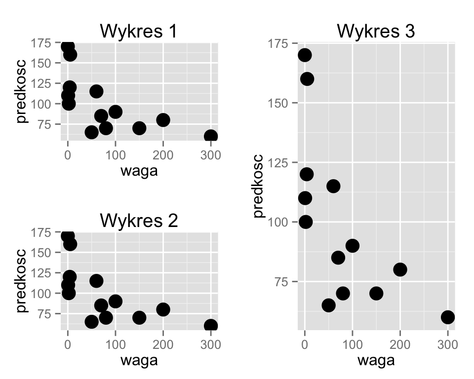

```r
library(grid)

print(pl_waga + ggtitle("Wykres 1"),
      vp=viewport(x=0.25, y = 0.75, width=0.5, height=0.5))
print(pl_waga + ggtitle("Wykres 2"),
      vp=viewport(x=0.25, y = 0.25, width=0.5, height=0.5))
print(pl_waga + ggtitle("Wykres 3"),
      vp=viewport(x=0.75, y = 0.5, width=0.5, height=1))
```

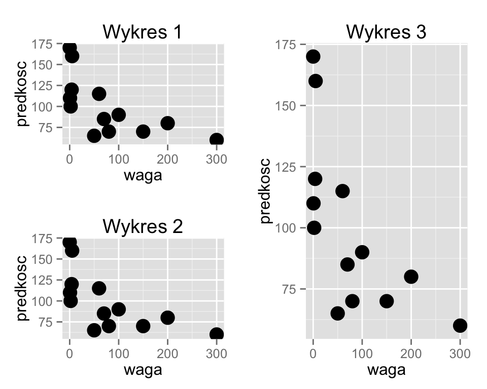

```r
# siatka:
pushViewport(viewport(layout = grid.layout(2,2)))
# wklejanie wykresow do wybranych cel:
print(pl_waga + ggtitle("Wykres 1"),
      vp= viewport(layout.pos.row=1, layout.pos.col=1))
print(pl_waga + ggtitle("Wykres 2"),
      vp= viewport(layout.pos.row=2, layout.pos.col=1))
print(pl_waga + ggtitle("Wykres 3"),
      vp= viewport(layout.pos.row=1:2, layout.pos.col=2))
```

# Motywy graficzne

Do tego miejsca mogło nam trochę obrzydnąć szare tło na wykresach. Okazuje się, że w prosty sposób można zmienić wygląd wykresu, używając motywów, czyli kompletów ustawień graficznych. Wiele takich motywów dostępnych jest w pakiecie `ggthemes`. Aby zmienić wygląd wykresu wystarczy dodać funkcję z motywem. Nazwy tych funkcji rozpoczynają się od `theme_`. Poniżej przykład dla czterech motywów graficznych.

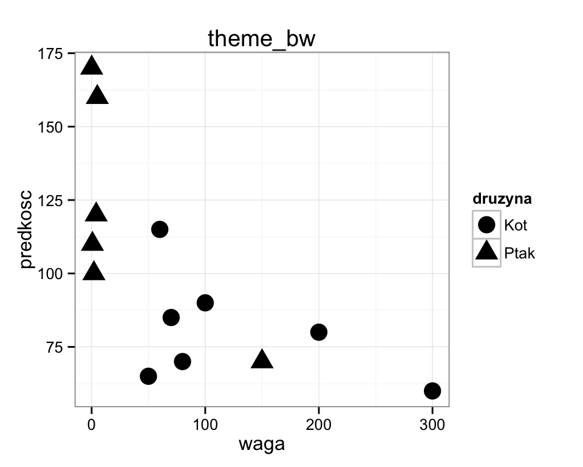

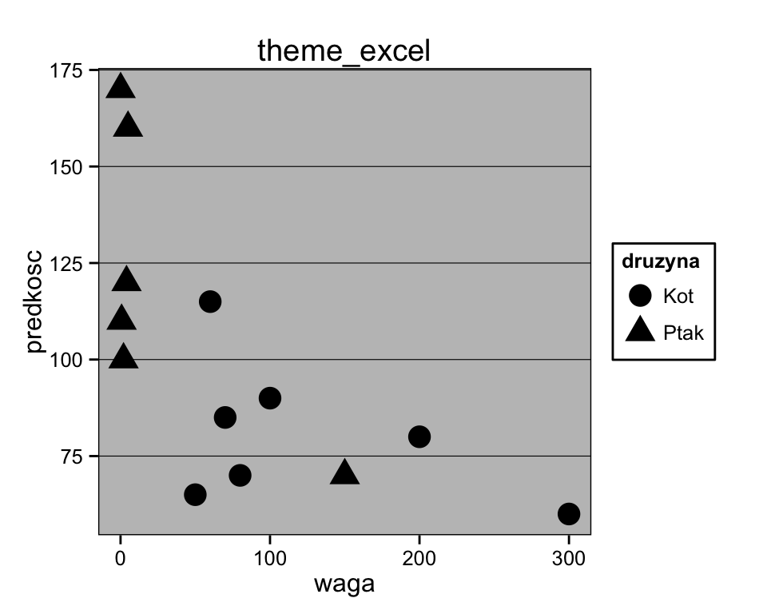

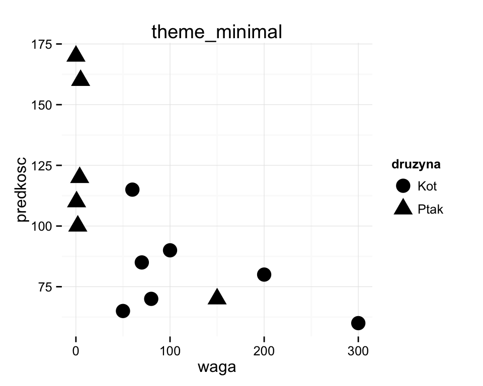

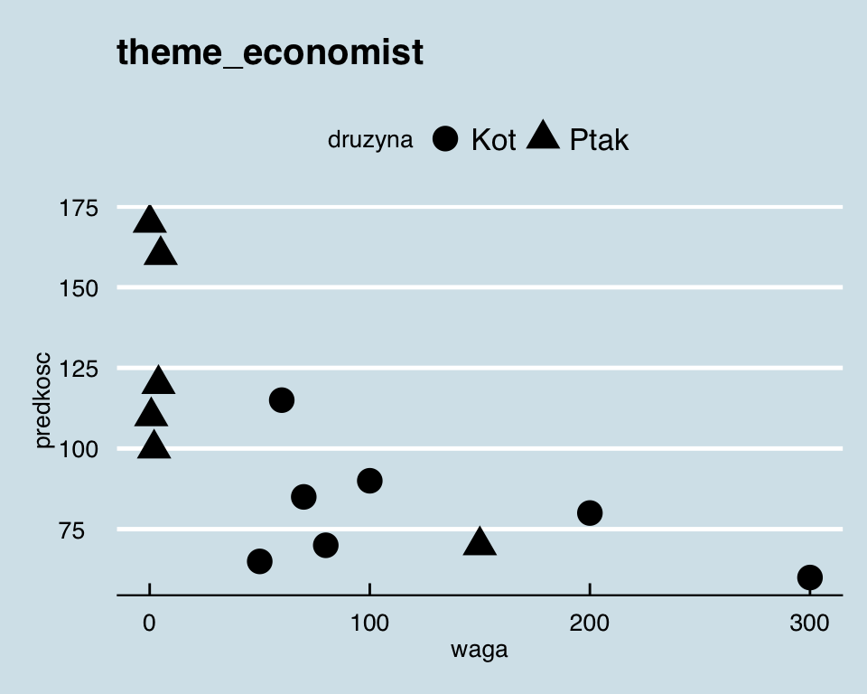

```r
library(ggthemes)
pl <- ggplot(koty_ptaki, aes(x=waga, y=predkosc, shape=druzyna)) +
  geom_point(size=5)
pl + theme_bw()
pl + theme_excel()
pl + theme_minimal()
pl + theme_economist()
```

# Ciekawostki

Elastyczność ggplot2 jest olbrzymia. Możliwe jest tworzenie wykresów w stylu popularnych komiksów z serii XKCD http://xkcd.com/

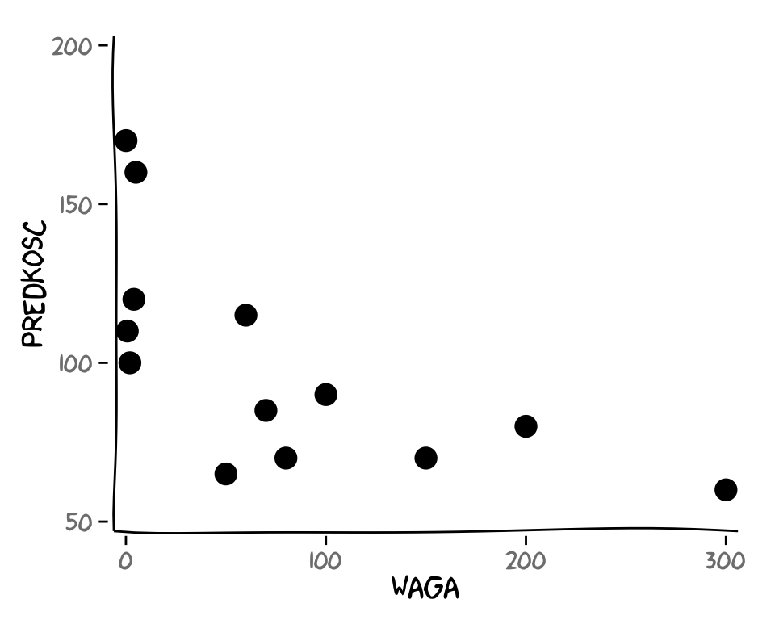

```r
library(xkcd)
ggplot(koty_ptaki, aes(x=waga, y=predkosc)) +
  geom_point(size=5) + xkcdaxis(c(0,300),c(50,200))
```

Bazując na motywie `theme_bw()` można uzyskać inwersję domyślnych wykresów z pakietu `ggplot2`

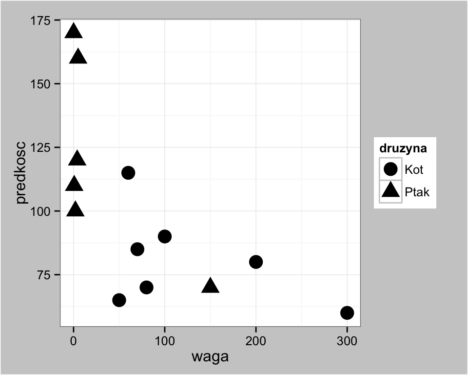

```r
pl + theme_bw()+theme(plot.background = element_rect(fill = "gray80"))
```

# Co dalej

Do’s and Don’ts http://stat545-ubc.github.io/block015_graph-dos-donts.html

No no’s Do: make the data stand out Do: spare your reader from mental gymnastics Do: use position along a common scale Do: take control of aspect ratio Do: think about including zero Do: choose the scale with intention Do: connect the dots with care Do: convey groups clearly

Ten Simple Rules for Better Figures

http://www.ploscompbiol.org/article/info:doi/10.1371/journal.pcbi.1003833

Twenty rules for good graphics

http://robjhyndman.com/hyndsight/graphics/

# Co dalej

- Więcej informacji o tym jak budować wykresy w pakiecie ggplot2 znaleźć można w rozdziale 4 książki *,,Przewodnik po pakiecie R’’*. Więcej informacji o tej książce http://www.biecek.pl/R/
- Wiele przydatnych wskazówek można również znaleźć w internetowej książce *,,Cookbook for R’’* http://www.cookbook-r.com/Graphs/
- Bardzo rozbudowana dokumentacja dla pakietu ggplot2 dostępna jest na stronie *,,ggplot2’’* http://docs.ggplot2.org/current/index.html
- Effective tables and graphs in official statistics, Government Statistical Service (London) https://gss.civilservice.gov.uk/wp-content/uploads/2014/12/Effective-graphs-and-tables-in-official-statistics-version-1.pdf

INNE:

easyGgplot2 - nakłądki na pakiet ggplot2 http://www.sthda.com/english/wiki/easyggplot2

edytowalne wykresy dla ggplota [do excela lub worda] http://www.sthda.com/english/wiki/create-an-editable-graph-from-r-software